# Python for data analysis TD1

### Python ?

Python is a language:

- Interpretated (= compiled each time the program is run)
- easy to write and read because well spaced and idented: Line Breaks and tabs replace semi-colon and tabs
- Object oriented but can be written in a classic procedural way.
- Equipped with many libraries written by developers from many different backgrounds, and specially well equipped for our domain

### Data ?

- excel files
- comma separated values files
- tabulated value files
- text files
- json files
- image(s)
- any kind of content you could analyse to understand the structure and extract raw data : webscraping..
- ...
- un mélange des précédents formats, généralement reliées par un identifiant permettant l'alignement des donées ( database join ). par ex fichier csv ville /année / temperature, fichier csv ville / age moyen

Data providers :

- Open Government Data (OGD) : data.gov , data.gouv.fr ...
- Private Companies
- personaly collected ( Living room temperature log)
- collected and published by third parties : kaggle ..
- ...
- https://github.com/awesomedata/awesome-public-datasets
- https://catalog.data.gov/dataset
- https://www.data.gouv.fr/fr/
- https://www.kaggle.com/datasets
- https://archive.org/details/datasets
- https://commoncrawl.org/
- https://www.interviewqs.com/blog/free_online_data_sets ...

### Descriptive analytics : What happened ?

Make data "speak" Make them reveal things hard or impossible to say just by reading them Display graphically to increase comprehension

Descriptive Analysis is probably the most important process of Analysis which is basically exploring the data set, extracting knowledge from data using various Statistical Techniques and KNOWING YOUR DATA INSIDE OUT before you do any sort of Predictive Modelling and Anlaysis.

### Predictive analytics : What will happen ?

Predict something from a set of already made associations (image -> person name , image -> character, image -> category , image -> clothe name, customer service log -> subscription termination or not ...)

# 1.Data analyst toolbox installation

## 1.1 Python

We should use python 3 for maximum compatibility with new versions of the libraries

First verify what version is on your system

PLEASE NOTE THAN WHEN THE LINE STARTS WITH $ YOU SHOULD TYPE IT IN A TERMINAL WINDOW

```python
$ python
```

Si ça n'est pas la 3.8, il faut l'installer :

**Ubuntu:**

```python
$ sudo apt-get update
$ sudo apt-get install python3.8 python3-pip
```

**Mac:** ( https://installpython3.com/mac/ )

jusque mac OS 10.15 python 2.7 est installé en série.

ATTENTION ! ne pas supprimer la version livrée en série, elle est nécéssaire au système.

pour savoir si vous avez aussi la 3 :

```python
$ python3
```

sinon il faut l'installer. Les deux versions vont ensuite cohabiter sur votre système

Nous allons utiliser hombrew , un gestionnaire de paquet mac OS très pratique. Homebrew a besoin du compilateur gcc , inclus dans Xcode.

installation xcode

```python
$ xcode-select --install
```

installation Homebrew : allez sur https://brew.sh/ puis copier collez la commande shell

```python
$ /bin/bash -c "$(curl -fsSL https://raw.githubusercontent.com/Homebrew/install/master/install.sh)"
```

installation python 3 et pip

```python
$ brew install python3
```

ATTENTION ! python / python3 pip / pip3

pour utiliser python 3 : lancez toujours python avec python3 et pip avec pip3

**Windows** ( https://installpython3.com/windows/ )

- depuis le micrososft store à partir de windows 10
- sinon telecharger le binaire depuis le site python https://www.python.org/downloads/windows/

### 1.2 Jupyter Notebook

- Edition et Execution du code sur une page web, avec conservation de l'historique
- Affichage matplotlib integré
- Affichage markdown
- Sauvegarde du notebook en local, publication simple sur github, accessible en ligne..
- Très utilisé dans l'ecosysteme data science pour ces mêmes raisons.

Plutot que d'editer dans un éditeur et lancer son code dans un shell, ou de travailler dans un IDE, Jupyter permet de travailler dans le navigateur, tout en conservant un historique des executions. Ca permet de "raconter une histoire", de montrer l'évolution d'un raisonnement. Les notebooks peuvent être sauvegardés et échangés.

dans un shell :

```python
pip install notebook
```

ou

```python
pip3 install notebook
```

une fois installé, pour créez un notebook : créez un dossier pour ce cours , dans un terminal rendez vous dans ce dossier avec cd /chemin/vers/le/dossier (utilisez l'autocomplétion avec tab), puis lancez la commande :

```python
$ jupyter notebook
```

Un navigateur devrait s'ouvrir affichant la liste des fichiers contenus dans le dossier. Jupyter utilise un serveur web integré pour vous permettre de travailler en local dans le navigateur. ( Vous pourriez tout aussi bien travailler en distant)

Pour créer un notebook, cliquez sur "nouveau" en haut à droite puis choisissez python3

renommez le notebook, par exemple "python for data analysis TD1"

Saisissez du code python dans la première cellule, puis shift+ entrée pour l'executer.

```python
print("Hello World!")
```

Jupyter afficher la sortie du programme sous votre code, puis crée une nouvelle cellule. etc.. Vous gardez ainsi mémoire de la progression de votre code.

Chaque cellule peut devenir une cellule markdown : esc m faites shift entrée pour afficher le rendu markdown

( https://www.markdownguide.org/basic-syntax/ )

pour insérer une cellule avant ou après : esc a ou esc b

fichier est automatiquement sauvegardé à intervalles réguliers. vous pouvez le transmettre, ou le publier directement sur github.

( pour les fonctions additionnelles, --> O'Reilly)

```python
%autosave 60
```

### 1.3 Pandas

```python
pip install pandas
```

ou

```python
pip3 install pandas
```

### 1.4 Matplotlib

idem en remplçant pandas par matplotlib

```python
pip install matplotlib
```

# 2. Getting Started

## 2.1 Python

```python
print("hello world") # puis shift entrée ( ou alt entrée pour executer et inserer une nouveller cellule)
```

### Dynamic typing

```python
a=1
type(a)
# ?
```

```
int
```

```python
b=1.1
type(b)
```

```
float
```

```python
c="1"
type(c)
```

```
str
```

```python
d=True
type(d)
```

```
bool
```

### Type casting

```python
print(c + 2)
# ?
```

```
---------------------------------------------------------------------------
TypeError                                 Traceback (most recent call last)
<ipython-input-18-0748901053a5> in <module>
----> 1 print(c + 2)
      2 # ?

TypeError: can only concatenate str (not "int") to str
```

```python
print(c+"2")
```

```
12
```

pour additioner à un entier, python a besoin d'un entier ou d'un float.

```python
print(int(c)+2)
```

```
3
```

```python
print(a + "2")
```

```
---------------------------------------------------------------------------
TypeError                                 Traceback (most recent call last)
<ipython-input-6-b4001347a269> in <module>
----> 1 print(a + "2")

TypeError: unsupported operand type(s) for +: 'int' and 'str'
```

```python
print(str(a))
```

```
1
```

```python
print("2"+str(1))
```

```
21
```

pour concaténer avec une chaine, Python a besoin d'une chaine

```python
print(str(a)+"2")
```

```
12
```

### Lists

```python
une_liste = [1,2,"a", "b"]
une_liste
```

```
[1, 2, 'a', 'b']
```

```python
# les indices de listes commencent à 0
une_liste[2]
```

```
'a'
```

```python
# dernier élement de la liste
une_liste[-1]
```

```
'b'
```

```python
une_liste.append("z")
une_liste
```

```
[1, 2, 'a', 'b', 'z']
```

### List slicing

Permet de selectionner une sous partie d'une liste, en spécifiant l'index de début et l'index de fin syntaxe : liste[début:fin] ( fin non inclus )

```python
une_liste[2:4]
```

```
['a', 'b']
```

```python
une_liste[2:]
```

```
['a', 'b', 'z']
```

```python
une_liste[:3]
```

```
[1, 2, 'a']
```

```python
une_liste[-2:]
```

```
['b', 'z']
```

```python
une_liste[:-2]
```

```
[1, 2, 'a']
```

## 2.2 Pandas / Matplotlib

Pandas adds two new data structures to the classic python data structures ( list, dict, tuples, set) :

- Series : a one-dimensional labeled array capable of holding any data type
- DataFrame : a 2-dimensional labeled data structure with columns of potentially different types. You can think of it like a spreadsheet or SQL table, or a dict of Series objects.

you can find here an introduction to Pandas data structures : https://pandas.pydata.org/pandas-docs/stable/user_guide/dsintro.html

Matplotlib allows us to create quality plots with very little code.

```python
%matplotlib inline
```

```python
import pandas as pd
import matplotlib.pyplot as plt
```

```python
data=[0,1,2,3,4,5,6,7,8,9]
data
```

```
[0, 1, 2, 3, 4, 5, 6, 7, 8, 9]
```

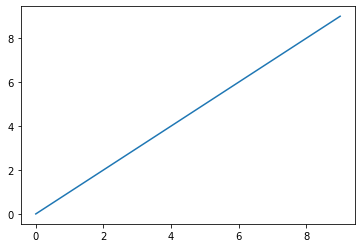

```python
plt.plot(data)
```

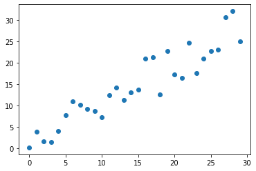

```python
# Here we will use some numpy functions to generate data, only to demo Matplotlib scatter and histogram plots
import numpy as np
plt.scatter(np.arange(30),np.arange(30) + 3 * np.random.randn(30))
```

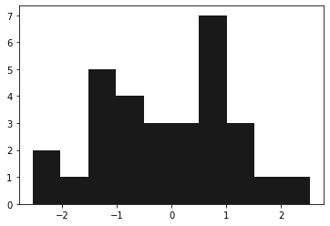

```python
plt.hist(np.random.randn(30), bins=10, color='k', alpha=0.9)
```

# 3. Our first real case : Insee France firstnames file, 1900 - 2018

Read ( translate ) description and documentation here https://www.insee.fr/fr/statistiques/2540004

Download the file : https://www.insee.fr/fr/statistiques/fichier/2540004/dpt2018_csv.zip

Move the file to the directory where you started jupyter

( Pandas allow to load the file directly from url but we like to have a copy of the file on the computer )

### 3.1 Loading of the dataset in a DataFrame

```python
prenoms= pd.read_csv("dpt2018.csv",sep=";")
```

if you moved and renamed the file you could do :

```python
prenoms= pd.read_csv("datasets/prenoms_fr_1900_2018_insee.csv",sep=";")
```

```python
# when you print the variable, pandas show an extract column names,
# first and last lines, index number and some more information
prenoms
```

|  | sexe | preusuel | annais | dpt | nombre |
| --- | --- | --- | --- | --- | --- |
| 0 | 1 | A | XXXX | XX | 27 |
| 1 | 1 | AADAM | XXXX | XX | 27 |
| 2 | 1 | AADEL | XXXX | XX | 55 |
| 3 | 1 | AADIL | 1983 | 84 | 3 |
| 4 | 1 | AADIL | 1992 | 92 | 3 |
| ... | ... | ... | ... | ... | ... |
| 3624989 | 2 | ÉYA | 2014 | 69 | 3 |
| 3624990 | 2 | ÉYA | XXXX | XX | 23 |
| 3624991 | 2 | ÏNAYA | XXXX | XX | 21 |
| 3624992 | 2 | ÖZGE | XXXX | XX | 30 |
| 3624993 | 2 | ÖZLEM | XXXX | XX | 95 |

3624994 rows × 5 columns

### 3.2 Pandas allow Quick analysis of content and structure of the dataset

```python
prenoms.head() # Affiche la ligne d'en tête et les 5 premières ligne, avec l'index créé automatiquement.
```

|  | sexe | preusuel | annais | dpt | nombre |
| --- | --- | --- | --- | --- | --- |
| 0 | 1 | A | XXXX | XX | 27 |
| 1 | 1 | AADAM | XXXX | XX | 27 |
| 2 | 1 | AADEL | XXXX | XX | 55 |
| 3 | 1 | AADIL | 1983 | 84 | 3 |
| 4 | 1 | AADIL | 1992 | 92 | 3 |

```python
prenoms.tail()
```

|  | sexe | preusuel | annais | dpt | nombre |
| --- | --- | --- | --- | --- | --- |
| 3624989 | 2 | ÉYA | 2014 | 69 | 3 |
| 3624990 | 2 | ÉYA | XXXX | XX | 23 |
| 3624991 | 2 | ÏNAYA | XXXX | XX | 21 |
| 3624992 | 2 | ÖZGE | XXXX | XX | 30 |
| 3624993 | 2 | ÖZLEM | XXXX | XX | 95 |

```python
nb_lignes, nb_col = prenoms.shape
print(nb_lignes)
print(nb_col)
```

```
3624994
5
```

```python
prenoms.describe()
```

|  | sexe | nombre |
| --- | --- | --- |
| count | 3.624994e+06 | 3.624994e+06 |
| mean | 1.536878e+00 | 2.348677e+01 |
| std | 4.986382e-01 | 8.047885e+01 |
| min | 1.000000e+00 | 3.000000e+00 |
| 25% | 1.000000e+00 | 4.000000e+00 |
| 50% | 2.000000e+00 | 7.000000e+00 |
| 75% | 2.000000e+00 | 1.900000e+01 |
| max | 2.000000e+00 | 6.328000e+03 |

```python
prenoms.dtypes
```

```
sexe         int64
preusuel    object
annais      object
dpt         object
nombre       int64
dtype: object
```

```python
prenoms.columns
```

```
Index(['sexe', 'preusuel', 'annais', 'dpt', 'nombre'], dtype='object')
```

```python
# info Print a concise summary of a DataFrame.
prenoms.info()
```

```
<class 'pandas.core.frame.DataFrame'>
RangeIndex: 3624994 entries, 0 to 3624993
Data columns (total 5 columns):
 #   Column    Dtype
---  ------    -----
 0   sexe      int64
 1   preusuel  object
 2   annais    object
 3   dpt       object
 4   nombre    int64
dtypes: int64(2), object(3)
memory usage: 138.3+ MB
```

**EXERCISE 1**

### find 3 questions to ask to this dataset, and 3 graphics to display

be precise with the name

### 3.3 COUNT

```python
prenoms.count()
```

```
sexe        3624994
preusuel    3624993
annais      3624994
dpt         3624994
nombre      3624994
dtype: int64
```

### 3.4 FILTER

```python
prenoms[prenoms.preusuel=="GERMAIN"]
```

|  | sexe | preusuel | annais | dpt | nombre |
| --- | --- | --- | --- | --- | --- |
| 593637 | 1 | GERMAIN | 1900 | 02 | 8 |
| 593638 | 1 | GERMAIN | 1900 | 04 | 3 |
| 593639 | 1 | GERMAIN | 1900 | 06 | 4 |
| 593640 | 1 | GERMAIN | 1900 | 07 | 11 |
| 593641 | 1 | GERMAIN | 1900 | 09 | 6 |
| ... | ... | ... | ... | ... | ... |
| 597525 | 1 | GERMAIN | 2018 | 75 | 3 |
| 597526 | 1 | GERMAIN | XXXX | XX | 4791 |
| 2432014 | 2 | GERMAIN | 1953 | 972 | 3 |
| 2432015 | 2 | GERMAIN | 1954 | 972 | 3 |
| 2432016 | 2 | GERMAIN | XXXX | XX | 120 |

3893 rows × 5 columns

```python
prenoms[prenoms.preusuel=="GERMAIN"].count()
```

```
sexe        3893
preusuel    3893
annais      3893
dpt         3893
nombre      3893
dtype: int64
```

```python
prenoms[prenoms.dpt=="XX"]
```

|  | sexe | preusuel | annais | dpt | nombre |
| --- | --- | --- | --- | --- | --- |
| 0 | 1 | A | XXXX | XX | 27 |
| 1 | 1 | AADAM | XXXX | XX | 27 |
| 2 | 1 | AADEL | XXXX | XX | 55 |
| 5 | 1 | AADIL | XXXX | XX | 175 |
| 7 | 1 | AAHIL | XXXX | XX | 17 |
| ... | ... | ... | ... | ... | ... |
| 3624988 | 2 | ÉVY | XXXX | XX | 89 |
| 3624990 | 2 | ÉYA | XXXX | XX | 23 |
| 3624991 | 2 | ÏNAYA | XXXX | XX | 21 |
| 3624992 | 2 | ÖZGE | XXXX | XX | 30 |
| 3624993 | 2 | ÖZLEM | XXXX | XX | 95 |

35608 rows × 5 columns

```python
prenoms[prenoms.dpt=="XX"].count()
```

```
sexe        35608
preusuel    35607
annais      35608
dpt         35608
nombre      35608
dtype: int64
```

```python
prenoms[prenoms.dpt != "XX"].count()
```

```
sexe        3589386
preusuel    3589386
annais      3589386
dpt         3589386
nombre      3589386
dtype: int64
```

### 3.5 SELECT ONE OR MORE COLUMNS

```python
# Choix d'une colonne
prenoms["sexe"]
```

```
0          1
1          1
2          1
3          1
4          1
          ..
3624989    2
3624990    2
3624991    2
3624992    2
3624993    2
Name: sexe, Length: 3624994, dtype: int64
```

```python
prenoms[prenoms.preusuel=="GERMAIN"]["sexe"]
```

```
593637     1
593638     1
593639     1
593640     1
593641     1
          ..
597525     1
597526     1
2432014    2
2432015    2
2432016    2
Name: sexe, Length: 3893, dtype: int64
```

```python
prenoms[prenoms['nombre'] > 3000]
```

|  | sexe | preusuel | annais | dpt | nombre |
| --- | --- | --- | --- | --- | --- |
| 9823 | 1 | ABEL | XXXX | XX | 5157 |
| 11905 | 1 | ACHILLE | XXXX | XX | 3624 |
| 27318 | 1 | ADRIEN | XXXX | XX | 3123 |
| 34020 | 1 | AIME | XXXX | XX | 3311 |
| 37355 | 1 | ALAIN | 1946 | 75 | 3362 |
| ... | ... | ... | ... | ... | ... |
| 3556186 | 2 | VICTORINE | XXXX | XX | 3689 |
| 3560253 | 2 | VIOLETTE | XXXX | XX | 5508 |
| 3565046 | 2 | VIRGINIE | XXXX | XX | 3068 |
| 3568667 | 2 | VIVIANE | XXXX | XX | 3311 |
| 3580402 | 2 | YASMINA | XXXX | XX | 3248 |

384 rows × 5 columns

### 3.6 SORT

```python
prenoms.sort_values(by="preusuel")
```

|  | sexe | preusuel | annais | dpt | nombre |
| --- | --- | --- | --- | --- | --- |
| 0 | 1 | A | XXXX | XX | 27 |
| 1 | 1 | AADAM | XXXX | XX | 27 |
| 2 | 1 | AADEL | XXXX | XX | 55 |
| 3 | 1 | AADIL | 1983 | 84 | 3 |
| 4 | 1 | AADIL | 1992 | 92 | 3 |
| ... | ... | ... | ... | ... | ... |
| 3624992 | 2 | ÖZGE | XXXX | XX | 30 |
| 1678812 | 1 | ÖZGÜR | XXXX | XX | 23 |
| 1678813 | 1 | ÖZKAN | XXXX | XX | 22 |
| 3624993 | 2 | ÖZLEM | XXXX | XX | 95 |
| 3167492 | 2 | NaN | XXXX | XX | 31 |

3624994 rows × 5 columns

```python
prenoms.sort_values(by='nombre')
```

|  | sexe | preusuel | annais | dpt | nombre |
| --- | --- | --- | --- | --- | --- |
| 950867 | 1 | LINO | 2012 | 20 | 3 |
| 3397765 | 2 | SAMIRA | 2012 | 72 | 3 |
| 3397764 | 2 | SAMIRA | 2012 | 67 | 3 |
| 3397763 | 2 | SAMIRA | 2012 | 38 | 3 |
| 3397762 | 2 | SAMIRA | 2012 | 06 | 3 |
| ... | ... | ... | ... | ... | ... |
| 1123654 | 1 | MAX | XXXX | XX | 5558 |
| 1808440 | 2 | ANGELINE | XXXX | XX | 5591 |
| 742602 | 1 | JEAN | 1947 | 75 | 5802 |
| 2107312 | 2 | CLOTILDE | XXXX | XX | 5831 |
| 742508 | 1 | JEAN | 1946 | 75 | 6328 |

3624994 rows × 5 columns

```python
# SORT AND SLICE
prenoms.sort_values(by='nombre')[-20:]
```

|  | sexe | preusuel | annais | dpt | nombre |
| --- | --- | --- | --- | --- | --- |
| 597526 | 1 | GERMAIN | XXXX | XX | 4791 |
| 2838272 | 2 | LYDIE | XXXX | XX | 4870 |
| 691808 | 1 | HUGUES | XXXX | XX | 4878 |
| 2384919 | 2 | FRANCE | XXXX | XX | 4916 |
| 3316430 | 2 | RACHEL | XXXX | XX | 5040 |
| 552097 | 1 | FÉLIX | XXXX | XX | 5080 |
| 669783 | 1 | HENRY | XXXX | XX | 5096 |
| 1076909 | 1 | MARTIAL | XXXX | XX | 5131 |
| 2820207 | 2 | LUCILE | XXXX | XX | 5145 |
| 9823 | 1 | ABEL | XXXX | XX | 5157 |
| 2317688 | 2 | ESTHER | XXXX | XX | 5174 |
| 1651824 | 1 | YVAN | XXXX | XX | 5238 |
| 1991491 | 2 | CARMEN | XXXX | XX | 5330 |
| 407132 | 1 | ELIE | XXXX | XX | 5337 |
| 3560253 | 2 | VIOLETTE | XXXX | XX | 5508 |
| 1123654 | 1 | MAX | XXXX | XX | 5558 |
| 1808440 | 2 | ANGELINE | XXXX | XX | 5591 |
| 742602 | 1 | JEAN | 1947 | 75 | 5802 |
| 2107312 | 2 | CLOTILDE | XXXX | XX | 5831 |
| 742508 | 1 | JEAN | 1946 | 75 | 6328 |

```python
# FILTER , SORT , SLICE
prenoms[prenoms.preusuel=="GERMAIN"].sort_values(by='nombre')[-10:]
```

|  | sexe | preusuel | annais | dpt | nombre |
| --- | --- | --- | --- | --- | --- |
| 594601 | 1 | GERMAIN | 1912 | 75 | 35 |
| 595629 | 1 | GERMAIN | 1927 | 59 | 36 |
| 594154 | 1 | GERMAIN | 1907 | 12 | 37 |
| 594392 | 1 | GERMAIN | 1910 | 19 | 38 |
| 593963 | 1 | GERMAIN | 1904 | 59 | 42 |
| 595095 | 1 | GERMAIN | 1920 | 59 | 43 |
| 595551 | 1 | GERMAIN | 1926 | 59 | 43 |
| 595318 | 1 | GERMAIN | 1923 | 59 | 45 |
| 2432016 | 2 | GERMAIN | XXXX | XX | 120 |
| 597526 | 1 | GERMAIN | XXXX | XX | 4791 |

```python
# Reverse Order
prenoms[prenoms['nombre'] > 3000].sort_values(by="nombre", ascending=False)
```

|  | sexe | preusuel | annais | dpt | nombre |
| --- | --- | --- | --- | --- | --- |
| 742508 | 1 | JEAN | 1946 | 75 | 6328 |
| 2107312 | 2 | CLOTILDE | XXXX | XX | 5831 |
| 742602 | 1 | JEAN | 1947 | 75 | 5802 |
| 1808440 | 2 | ANGELINE | XXXX | XX | 5591 |
| 1123654 | 1 | MAX | XXXX | XX | 5558 |
| ... | ... | ... | ... | ... | ... |
| 37823 | 1 | ALAIN | 1951 | 75 | 3014 |
| 3410953 | 2 | SARA | XXXX | XX | 3012 |
| 2009466 | 2 | CATHERINE | 1960 | 75 | 3012 |
| 3503564 | 2 | SYLVIE | 1964 | 75 | 3011 |
| 2103885 | 2 | CLOTHILDE | XXXX | XX | 3004 |

384 rows × 5 columns

### 3.7 Aggregate

```python
# GROUP BY
prenoms.groupby("sexe").nombre.sum()
```

```
sexe
1    42888936
2    42250453
Name: nombre, dtype: int64
```

```python
# Top des départements avec le plus et le moins de naissances
prenoms.groupby("dpt").nombre.sum().sort_values()
```

```
dpt
48      104399
04      105739
05      126071
09      156535
973     169185
        ...
69     2073802
62     2350845
59     4175920
75     6160048
XX     8261688
Name: nombre, Length: 100, dtype: int64
```

```python
# All time - All departements top 20
prenoms.groupby("preusuel").nombre.sum().sort_values()[-20:]
```

```
preusuel
DOMINIQUE          409919
PAUL               416412
ROBERT             419297
ROGER              423873
DANIEL             435021
MARCEL             467850
CLAUDE             468445
BERNARD            469399
JACQUES            482812
ALAIN              506899
RENÉ               516739
LOUIS              517774
PHILIPPE           538661
JEANNE             556074
ANDRÉ              712568
MICHEL             820459
PIERRE             891894
_PRENOMS_RARES    1575032
JEAN              1917129
MARIE             2260236
Name: nombre, dtype: int64
```

```python
# All time - All departements 20 prénoms les moins donnés (*)
prenoms.groupby(prenoms.preusuel).nombre.sum().sort_values()[:20]
```

```
preusuel
SCHÉRAZADE     20
SHYM           20
SHYMA          20
GIANMARCO      20
MPALY          20
BETHEL         20
ROMILDE        20
GIBRYL         20
LIRA           20
IMRANA         20
LIOVA          20
SHYNNA         20
MARC-ALBERT    20
NOLWAN         20
ALIHA          20
ALIFA          20
LIOBA          20
GILAINE        20
KACIA          20
MARC'ANTO      20
Name: nombre, dtype: int64
```

```python
# 10 prenoms les plus frequents de 2018
prenoms[(prenoms.annais=="2018")].groupby(prenoms.preusuel).nombre.sum().sort_values()[-10:]
```

```
preusuel
LOUISE             3765
ADAM               3885
JADE               3977
LUCAS              3978
EMMA               4367
LOUIS              4411
LÉO                4444
RAPHAËL            4589
GABRIEL            5418
_PRENOMS_RARES    53978
Name: nombre, dtype: int64
```

### 3.8 Data "Cleaning"

All the lines where the number of births would have been less than 3 are condensed on a single line with dpt =XX and birth year = XXXX

PLEASE BE CAREFUL: THESE LINES ARE NOT "WRONG" or "INCORRECT". They mean something that can be precious depending on the question you're asking. If you want to know something over the whole period and the whole country, you need to keep it. But in some case, they can be a problem.

Let's get rid of these lines :

```python
prenoms[(prenoms.dpt == "XX")].count()
```

```
sexe        35608
preusuel    35607
annais      35608
dpt         35608
nombre      35608
dtype: int64
```

```python
prenoms[(prenoms.dpt != "XX")].count()
```

```
sexe        3589386
preusuel    3589386
annais      3589386
dpt         3589386
nombre      3589386
dtype: int64
```

```python
prenoms.count()
```

```
sexe        3624994
preusuel    3624993
annais      3624994
dpt         3624994
nombre      3624994
dtype: int64
```

```python
prenoms=prenoms[(prenoms.dpt != "XX")]
prenoms.count()
```

```
sexe        3589386
preusuel    3589386
annais      3589386
dpt         3589386
nombre      3589386
dtype: int64
```

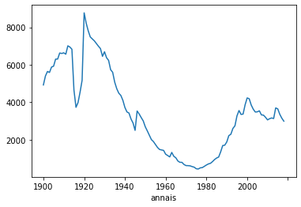

```python
prenoms[(prenoms.preusuel=="PAUL")].groupby("annais").nombre.sum().plot()
```

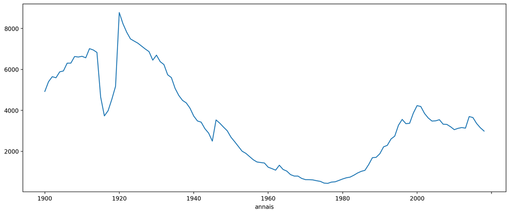

```python
plt.rcParams['figure.figsize'] = [15, 6] # Taille du graphique en pouces
plt.rcParams['figure.dpi'] = 200 # résolution en points par pouce
prenoms[(prenoms.preusuel=="PAUL")].groupby("annais").nombre.sum().plot()
```

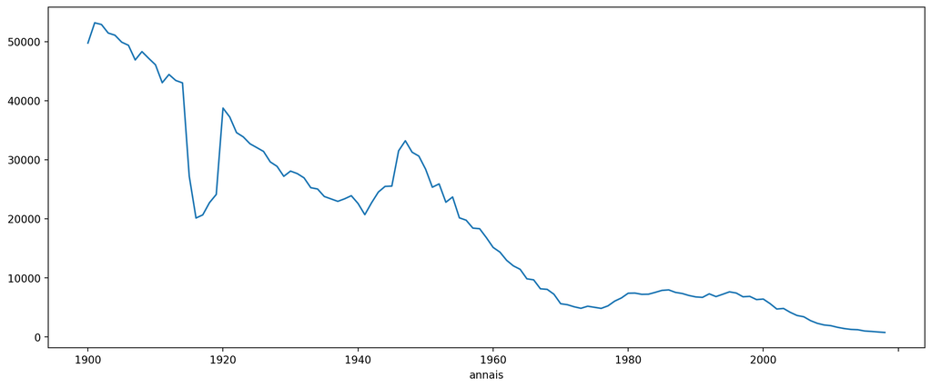

```python
prenoms[(prenoms.preusuel=="MARIE")].groupby("annais").nombre.sum().plot()
```

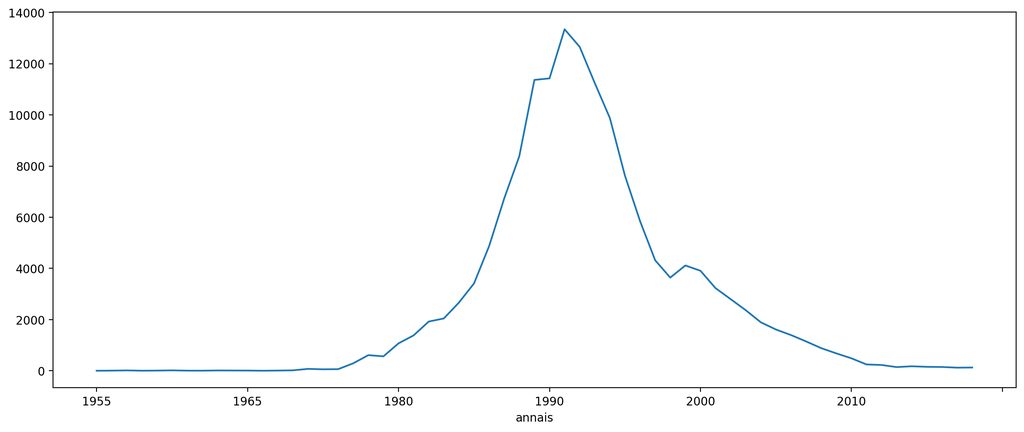

```python
prenoms[(prenoms.preusuel=="KEVIN")].groupby("annais").nombre.sum().plot()
```

```python
prenoms[prenoms.preusuel=="GAETAN"].sort_values(by='annais')
```

|  | sexe | preusuel | annais | dpt | nombre |
| --- | --- | --- | --- | --- | --- |
| 566481 | 1 | GAETAN | 2010 | 06 | 4 |
| 566512 | 1 | GAETAN | 2010 | 974 | 6 |
| 566511 | 1 | GAETAN | 2010 | 95 | 5 |
| 566510 | 1 | GAETAN | 2010 | 94 | 3 |
| 566509 | 1 | GAETAN | 2010 | 92 | 4 |
| ... | ... | ... | ... | ... | ... |
| 566582 | 1 | GAETAN | 2016 | 44 | 3 |
| 566580 | 1 | GAETAN | 2016 | 13 | 6 |
| 566583 | 1 | GAETAN | 2016 | 51 | 7 |
| 566584 | 1 | GAETAN | 2017 | 13 | 5 |
| 566585 | 1 | GAETAN | 2017 | 31 | 8 |

105 rows × 5 columns

```python
prenoms[prenoms.preusuel=="GAETAN"].sort_values(by='annais',ascending=False)
```

|  | sexe | preusuel | annais | dpt | nombre |
| --- | --- | --- | --- | --- | --- |
| 566585 | 1 | GAETAN | 2017 | 31 | 8 |
| 566584 | 1 | GAETAN | 2017 | 13 | 5 |
| 566583 | 1 | GAETAN | 2016 | 51 | 7 |
| 566582 | 1 | GAETAN | 2016 | 44 | 3 |
| 566581 | 1 | GAETAN | 2016 | 31 | 10 |
| ... | ... | ... | ... | ... | ... |
| 566509 | 1 | GAETAN | 2010 | 92 | 4 |
| 566510 | 1 | GAETAN | 2010 | 94 | 3 |
| 566511 | 1 | GAETAN | 2010 | 95 | 5 |
| 566512 | 1 | GAETAN | 2010 | 974 | 6 |
| 566481 | 1 | GAETAN | 2010 | 06 | 4 |

105 rows × 5 columns

### 3.9 Pivot table

A pivot table allows you to create new tables to display data aggregates. You need to tell pandas

- what data will be aggregated (number of births ? year of birth ?)
- what to display in columns
- what to display in lines
- what calculation to make on the aggregate data ( sum, average..

```python
# TABLE OF THE TOTAL NUMBER OF BOYS BIRTHS AND GIRLS BIRTHS PER YEAR
total_naissances=prenoms.pivot_table('nombre',index='annais',columns='sexe',aggfunc=sum)
#total_naissances[total_naissances.annais=="1925"] IS ERROR !
# EXPLAIN WHY.
total_naissances[total_naissances.index=="1946"]
```

| sexe annais | 1 | 2 |
| --- | --- | --- |
| 1946 | 433711 | 405088 |

And, of course, you can diplay plots using this new table :

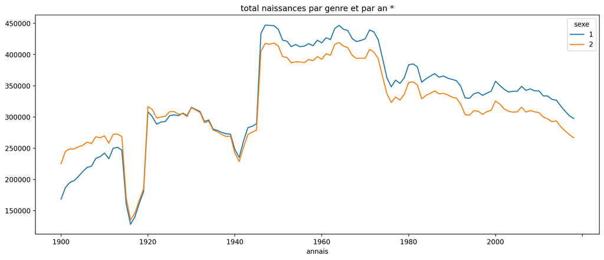

```python
total_naissances.plot(title="total naissances par genre et par an *")
```

# 4 a few tips for loading your files

Most of the time, problems come from the text encoding of the dataset, or to be more precise, from the fact that pandas can't guess the encoding of the file.

To find what is the encoding of your file, on mac or linux, use the "file" command line tool On windows, you could read this stackoverflow thread : https://stackoverflow.com/questions/3710374/get-encoding-of-a-file-in-windows

then give to read_csv the good encoding parameter :

```python
data = pd.read_csv("nameofmydataset.csv",sep=";",encoding='iso-8859-1')
```

Sometimes some lines are just corrupted :

```python
data = pd.read_csv('nameofmydataset.csv', error_bad_lines=False)
```

**EXERCISE 2**

### Find a dataset you understand

PLEASE BE CAREFUL : do not choose a dataset made for predictive analysis ( MNIST, Fashion MNIST, all Keras datasets...) , but a dataset made for descriptive analysis like the one we used in TD1 : historical log of meteo, pollution, traffic measurements, demographics or sports data... Any historical data should fit ( but this does not mean that data must be historical..)

### Import it into pandas, into a Jupyter Notebook.

### Find and answer 3 questions to ask using pandas, including aggregates.

### Find and display 3 plots using matplotlib, including pivot tables.

### Publish your notebook on GitHub or Collab

### I will ask some of you to show it and talk about it in the classroom..